# Empirical study for article

Steps:

- Estimate trawl function a
- Estimate $\widehat{Leb(A)} := \sum_{l=0}^{n-1}\hat a(l\Delta_n)\Delta_n$,
- Estimate $\widehat{ Leb(A\cap A_h)}:= \sum_{\substack{l\in \{0, \ldots, n-1\}:\\ l\Delta_n \geq h}} \hat a(l\Delta_n)\Delta_n$,
- Estimate $\widehat{Leb(A\setminus A_h)}:= \sum_{\substack{l\in \{0, \ldots, n-1\}:\\ l\Delta_n < h}} \hat a(l\Delta_n)\Delta_n$,
- Calculate $\overline X$.

```r
is_length <- 3000 #in sample length

my_lag <-is_length-1
my_Delta <-1/12#sampling in 5s=1/12 min





hrange <- 20
noos <- n-is_length-hrange #=941 for is_length=3000
#Create forecast matrices:
CondMean <-matrix(0, nrow=noos, ncol=hrange)
CondMean_IV <-matrix(0, nrow=noos, ncol=hrange)
CondMean_linear <-matrix(0, nrow=noos, ncol=hrange)
NaiveFC <-matrix(0, nrow=noos, ncol=hrange)
NaiveMeanFC <-matrix(0, nrow=noos, ncol=hrange)

ActualValues <- matrix(0, nrow=noos, ncol=hrange)

Weight_Intersection <- matrix(0, nrow=noos, ncol=hrange)
Weight_SetDifference <- matrix(0, nrow=noos, ncol=hrange)

Weight_Intersection_linear <- matrix(0, nrow=noos, ncol=hrange)
Weight_SetDifference_linear <- matrix(0, nrow=noos, ncol=hrange)


for(tau in 1:noos){
#tau<-1


  data <-x[tau:(is_length+tau-1)] # take new subsample of length is_length
  actualvalue <- x[(is_length+tau-1)]
  datamean <- mean(data) #sum(data)/(is_length) is also correct

  #Estimate trawl function
  esttrawlfct_fc <- nonpar_trawlest(data, Delta=my_Delta, lag=my_lag) #estimated trawl   function for forecasting

  #Differences between points for linear approximation (set sign to positive)
  diff_esttrawlfct_fc <- -diff(esttrawlfct_fc)

  #Estimate the Lebesgue measure of the trawl set (components)
  lebA_fc <-sum(esttrawlfct_fc)*my_Delta
  #Estimate the Lebesgue measure of the trawl set (components)
  #using linear approximation between points

  lebA_linear_fc <-sum(esttrawlfct_fc[2:my_lag])*my_Delta   +sum(diff_esttrawlfct_fc[2:(my_lag-1)])*my_Delta*0.5


  for(h in 1:hrange){ #forecasting horizon loop in 1:hrange
#h<-1
    #Estimate Leb(A intersection A_h)

    lebAintersection_fc <-sum(esttrawlfct_fc[(h+1):my_lag])*my_Delta

    lebAintersection_linear_fc <-sum(esttrawlfct_fc[(h+2):my_lag])*my_Delta   +sum(diff_esttrawlfct_fc[(h+1):(my_lag-1)])*my_Delta*0.5
    #Estimate Leb(A \ A_h)

    lebAsetdiff_fc <-lebA_fc-lebAintersection_fc#sum(esttrawlfct_fc[1:h])*my_Delta


    lebAsetdiff_linear_fc <-lebA_linear_fc-lebAintersection_linear_fc

    #ActualValue
    ActualValues[tau,h]<- x[(is_length+tau-1+h)]
    #Compute forecast(s)
    #naive
    NaiveFC[tau,h] <- actualvalue
    NaiveMeanFC[tau,h] <- datamean

    #trawl formula


    Weight_Intersection[tau, h]<-lebAintersection_fc/lebA_fc
    Weight_SetDifference[tau,h]<-lebAsetdiff_fc/lebA_fc

    Weight_Intersection_linear[tau, h]<-lebAintersection_linear_fc/lebA_linear_fc
    Weight_SetDifference_linear[tau,h]<-lebAsetdiff_linear_fc/lebA_linear_fc

    CondMean[tau,h] <- actualvalue*Weight_Intersection[tau, h]+datamean*Weight_SetDifference[tau,h]

    CondMean_IV[tau,h]<-round(CondMean[tau,h])

    CondMean_linear[tau,h] <- actualvalue*Weight_Intersection_linear[tau, h]+datamean*Weight_SetDifference_linear[tau,h]

  } #end for h

}#end for tau
```

Time for this code chunk to run: 17.0725328922272

We now estimate the error measures: MAE and MSE.

```r
my_mse <-function(x, y){
  length<-length(x)
  return(sum((x-y)^2)/length)
}

my_mae <-function(x, y){
  length<-length(x)
  return(sum(abs(x-y))/length)
}
```

Time for this code chunk to run: 0.00843214988708496

```r
#Computing the error measures

CondMean_MAE <- numeric(hrange)
CondMean_MSE <- numeric(hrange)

CondMean_IV_MAE <- numeric(hrange)
CondMean_IV_MSE <- numeric(hrange)

CondMean_linear_MAE <- numeric(hrange)
CondMean_linear_MSE <- numeric(hrange)

Naive_MAE <- numeric(hrange)
Naive_MSE <- numeric(hrange)

NaiveMean_MAE <- numeric(hrange)
NaiveMean_MSE <- numeric(hrange)

for(h in 1:hrange){
  CondMean_MAE[h] <-my_mae(CondMean[,h], ActualValues[,h])
  CondMean_MSE[h] <-my_mse(CondMean[,h], ActualValues[,h])

  CondMean_IV_MAE[h] <-my_mae(CondMean_IV[,h], ActualValues[,h])
  CondMean_IV_MSE[h] <-my_mse(CondMean_IV[,h], ActualValues[,h])

  CondMean_linear_MAE[h] <-my_mae(CondMean_linear[,h], ActualValues[,h])
  CondMean_linear_MSE[h] <-my_mse(CondMean_linear[,h], ActualValues[,h])

  Naive_MAE[h] <-my_mae(NaiveFC[,h], ActualValues[,h])
  Naive_MSE[h] <-my_mse(NaiveFC[,h], ActualValues[,h])

  NaiveMean_MAE[h] <-my_mae(NaiveMeanFC[,h], ActualValues[,h])
  NaiveMean_MSE[h] <-my_mse(NaiveMeanFC[,h], ActualValues[,h])
}

print(CondMean_MAE/Naive_MAE)
```

```
##  [1] 1.1565667 1.0760593 0.9965506 0.9590122 0.9273578 0.9282455 0.9351391
##  [8] 0.9369963 0.9380015 0.9233526 0.9304860 0.9438999 0.9337636 0.9471759
## [15] 0.9528876 0.9469802 0.9542714 0.9448099 0.9285099 0.9357964
```

```r
print(CondMean_MSE/Naive_MSE)
```

```
##  [1] 0.8498230 0.7809657 0.7356711 0.7074490 0.6952778 0.6866909 0.6921165
##  [8] 0.6945724 0.6974576 0.6763213 0.6744077 0.6850650 0.6825211 0.6901274
## [15] 0.6983637 0.6853182 0.6803471 0.6723534 0.6587796 0.6579287
```

```r
print(CondMean_IV_MAE/Naive_MAE)
```

```
##  [1] 1.1477328 1.0779783 0.9951397 0.9572745 0.9267390 0.9270477 0.9347079
##  [8] 0.9358739 0.9371563 0.9226251 0.9292465 0.9414962 0.9282625 0.9443155
## [15] 0.9496124 0.9445585 0.9526384 0.9406091 0.9274393 0.9349230
```

```r
print(CondMean_IV_MSE/Naive_MSE)
```

```
##  [1] 0.8595430 0.7883070 0.7377884 0.7104344 0.6990928 0.6924803 0.7000372
##  [8] 0.7003882 0.7022831 0.6794082 0.6767180 0.6806712 0.6779591 0.6880876
## [15] 0.6981914 0.6854818 0.6821238 0.6733715 0.6625980 0.6607428
```

```r
print(CondMean_linear_MAE/Naive_MAE)
```

```
##  [1] 1.0821154 1.0393991 0.9739880 0.9414572 0.9146586 0.9124873 0.9184578
##  [8] 0.9191171 0.9230021 0.9117360 0.9180976 0.9322115 0.9222085 0.9353086
## [15] 0.9394362 0.9354057 0.9416126 0.9364427 0.9202645 0.9268954
```

```r
print(CondMean_linear_MSE/Naive_MSE)
```

```
##  [1] 0.8599015 0.7819041 0.7358840 0.7067224 0.6924497 0.6815242 0.6840427
##  [8] 0.6844039 0.6879893 0.6701409 0.6668729 0.6762645 0.6728284 0.6793998
## [15] 0.6858742 0.6754398 0.6699823 0.6652422 0.6519772 0.6504360
```

```r
print(CondMean_linear_MAE/CondMean_MAE)
```

```
##  [1] 0.9356273 0.9659310 0.9773593 0.9816946 0.9863060 0.9830236 0.9821616
##  [8] 0.9809185 0.9840092 0.9874191 0.9866860 0.9876170 0.9876252 0.9874709
## [15] 0.9858835 0.9877775 0.9867346 0.9911440 0.9911197 0.9904884
```

```r
print(CondMean_linear_MSE/CondMean_MSE)
```

```
##  [1] 1.0118596 1.0012017 1.0002894 0.9989730 0.9959325 0.9924759 0.9883346
##  [8] 0.9853601 0.9864245 0.9908617 0.9888275 0.9871538 0.9857987 0.9844557
## [15] 0.9821161 0.9855857 0.9847654 0.9894234 0.9896742 0.9886117
```

Time for this code chunk to run: 0.0971760749816895

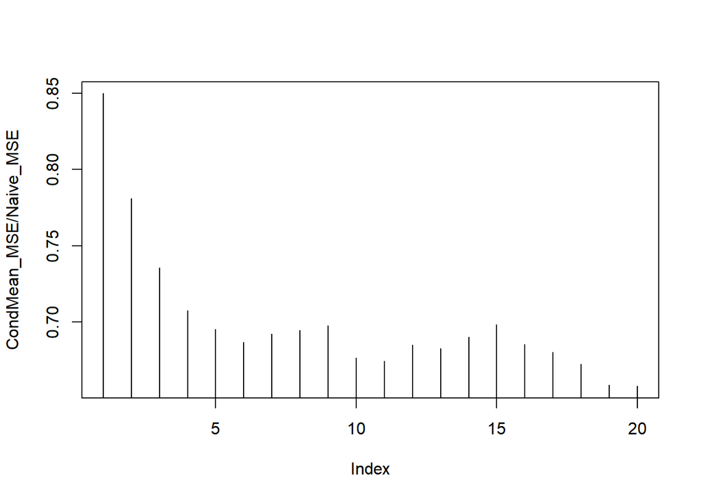

```r
#Plot the errors
plot(CondMean_MSE/Naive_MSE, type="h")
```

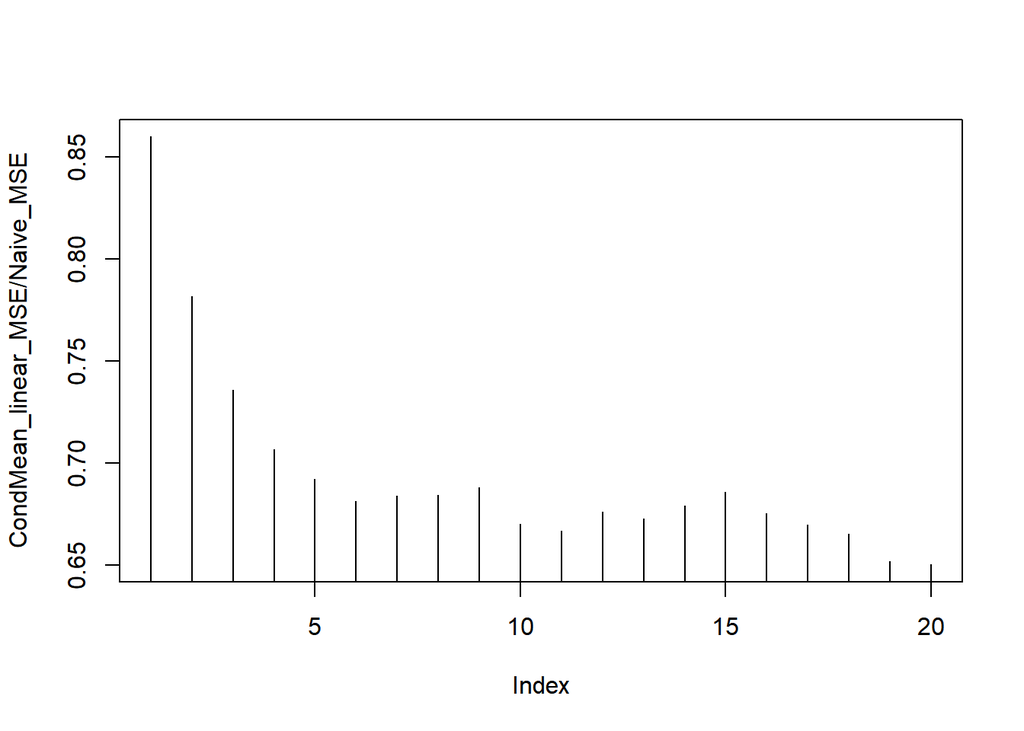

```r
plot(CondMean_linear_MSE/Naive_MSE, type="h")
```

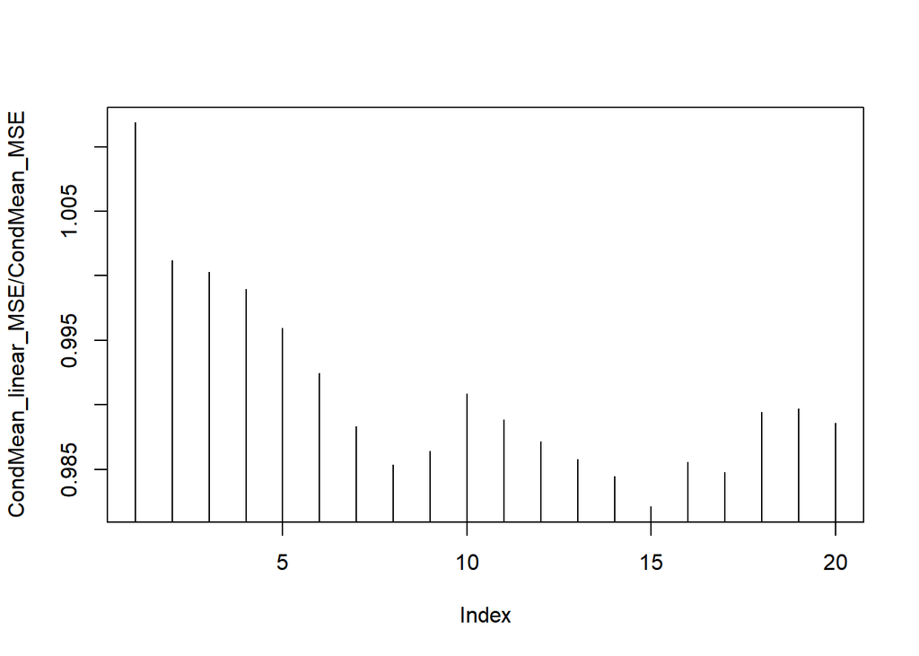

```r
plot(CondMean_linear_MSE/CondMean_MSE, type="h")
```

Time for this code chunk to run: 0.268477201461792

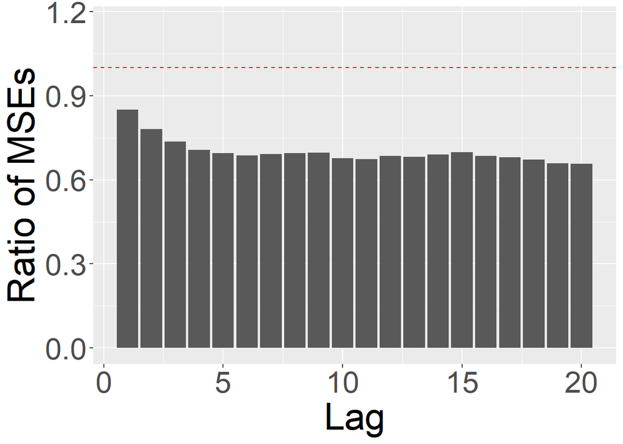

```r
#Plot the errors with ggplot
ratio1 <- CondMean_MSE/Naive_MSE
df1<-data.frame(lag=seq(1,20,1), ratio=ratio1)

df1p <-ggplot(data=df1, aes(x=lag, y=ratio))+
  geom_bar(stat="identity")+
  ylim(0,1.16)+
  geom_hline(yintercept=1, lty=2, col='red')+
  xlab("Lag")+
  ylab("Ratio of MSEs")
df1p
```

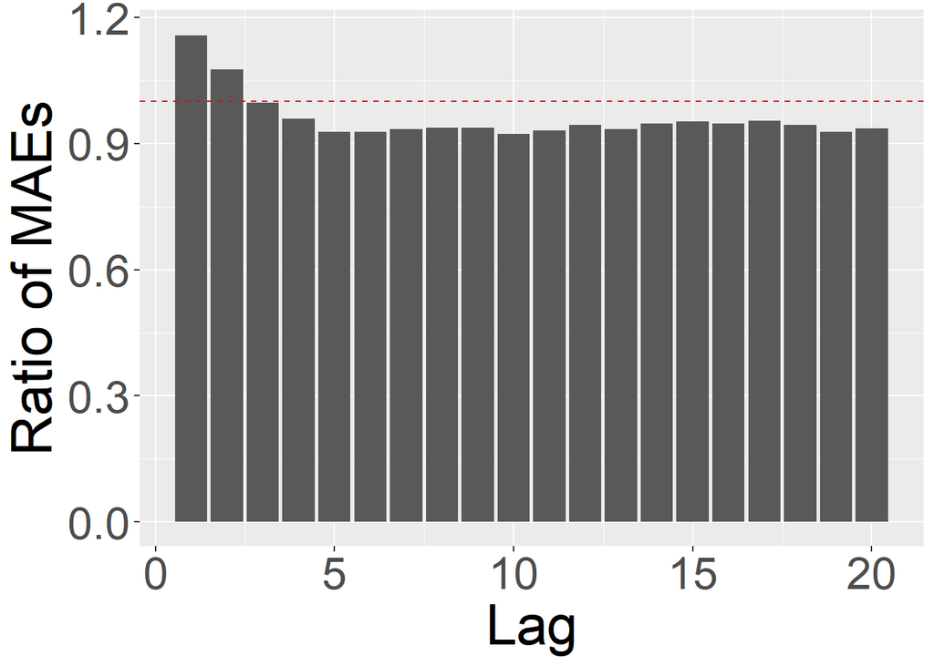

```r
ggsave("CondMean-Naive-MSE-ratio.eps", width = 20, height = 20, units = "cm")

ratio2 <- CondMean_MAE/Naive_MAE
df2<-data.frame(lag=seq(1,20,1), ratio=ratio2)

df2p <-ggplot(data=df2, aes(x=lag, y=ratio))+
  geom_bar(stat="identity")+
  ylim(0,1.16)+
  geom_hline(yintercept=1, lty=2, col='red')+
  xlab("Lag")+
  ylab("Ratio of MAEs")
df2p
```

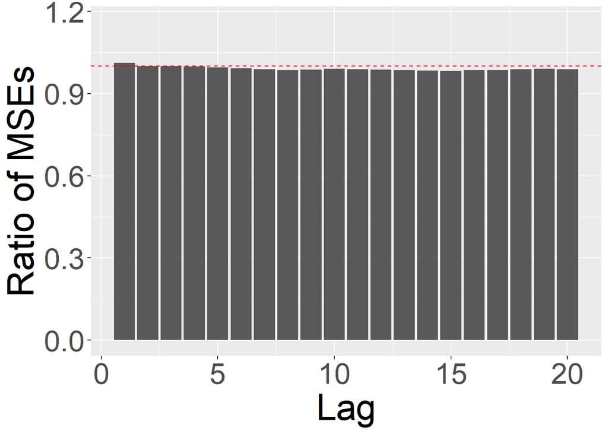

```r
ggsave("CondMean-Naive-MAE-ratio.eps", width = 20, height = 20, units = "cm")

ratio3 <- CondMean_linear_MSE/CondMean_MSE
df3<-data.frame(lag=seq(1,20,1), ratio=ratio3)

df3p <-ggplot(data=df3, aes(x=lag, y=ratio))+
  geom_bar(stat="identity")+
  ylim(0,1.16)+
  geom_hline(yintercept=1, lty=2, col='red')+
  xlab("Lag")+
  ylab("Ratio of MSEs")
df3p
```

```r
ggsave("CondMean_linear-CondMean-MSE-ratio.eps", width = 20, height = 20, units = "cm")

#plot(CondMean_linear_MSE/Naive_MSE, type="h")

#plot(CondMean_linear_MSE/CondMean_MSE, type="h")
```

Time for this code chunk to run: 1.87686800956726

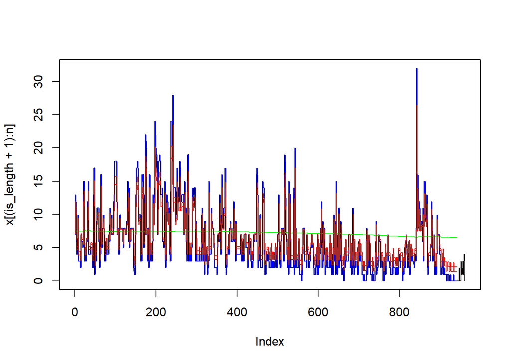

```r
plot(x[(is_length+1):n],type="l")
#lines(CondMean[,1])
lines(CondMean[,1],col="red")
lines(NaiveFC[,1],col="blue")
lines(NaiveMeanFC[,1],col="green")
lines(CondMean_linear[,1],col="brown")
```

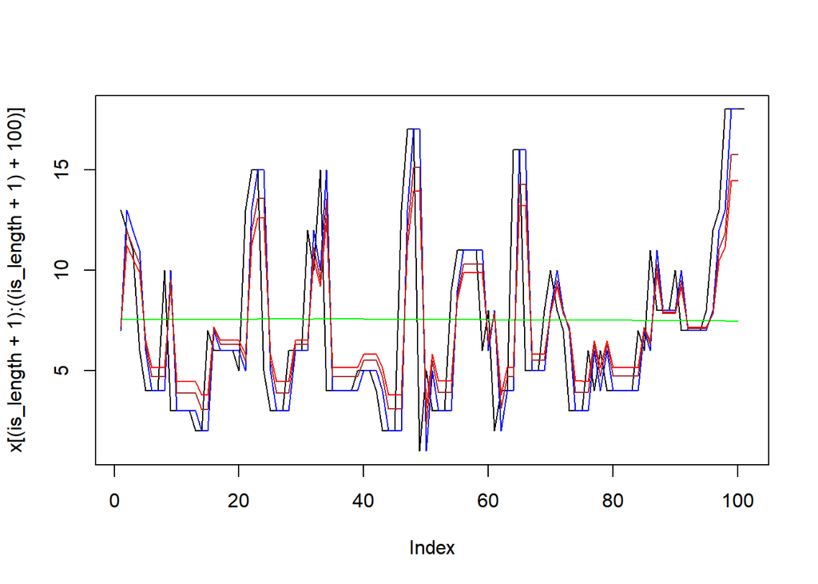

```r
plot(x[(is_length+1):((is_length+1)+100)],type="l")
#lines(CondMean[1:100,1])
lines(CondMean[1:100,1],col="red")
lines(NaiveFC[1:100,1],col="blue")
lines(NaiveMeanFC[1:100,1],col="green")
lines(CondMean_linear[1:100,1],col="brown")
```

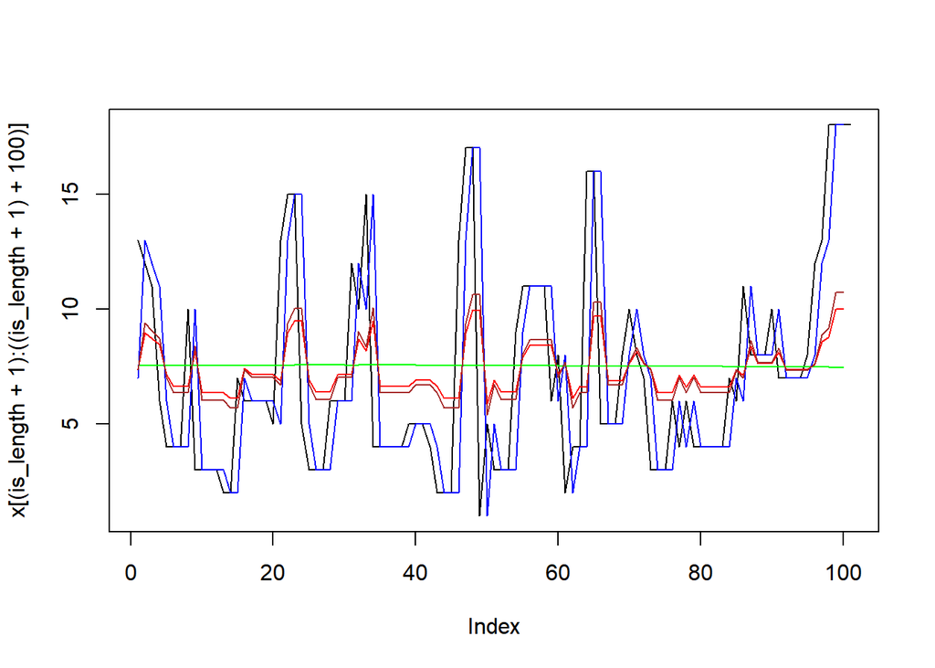

```r
plot(x[(is_length+1):((is_length+1)+100)],type="l")
#lines(CondMean[1:100,10])
lines(CondMean[1:100,10],col="red")
lines(NaiveFC[1:100,10],col="blue")
lines(NaiveMeanFC[1:100,10],col="green")
lines(CondMean_linear[1:100,10],col="brown")
```

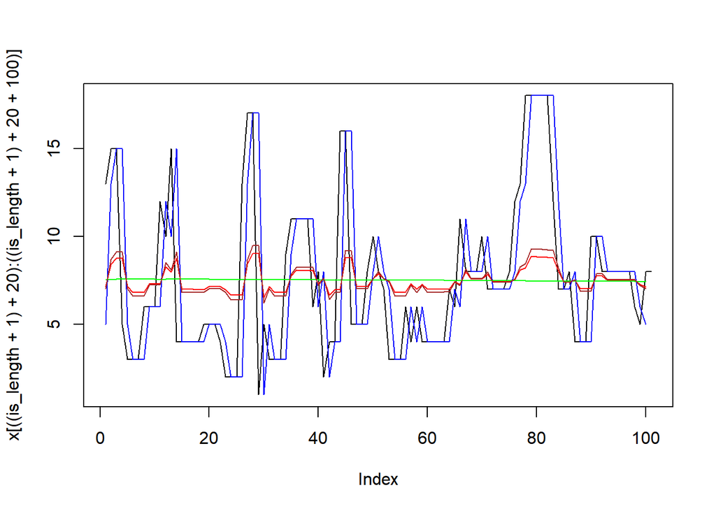

```r
plot(x[((is_length+1)+20):((is_length+1)+20+100)],type="l")
#lines(CondMean[1:100,10])
lines(CondMean[(1+20):(100+20),20],col="red")
lines(NaiveFC[(1+20):(100+20),20],col="blue")
lines(NaiveMeanFC[(1+20):(100+20),20],col="green")
lines(CondMean_linear[(1+20):(100+20),20],col="brown")
```

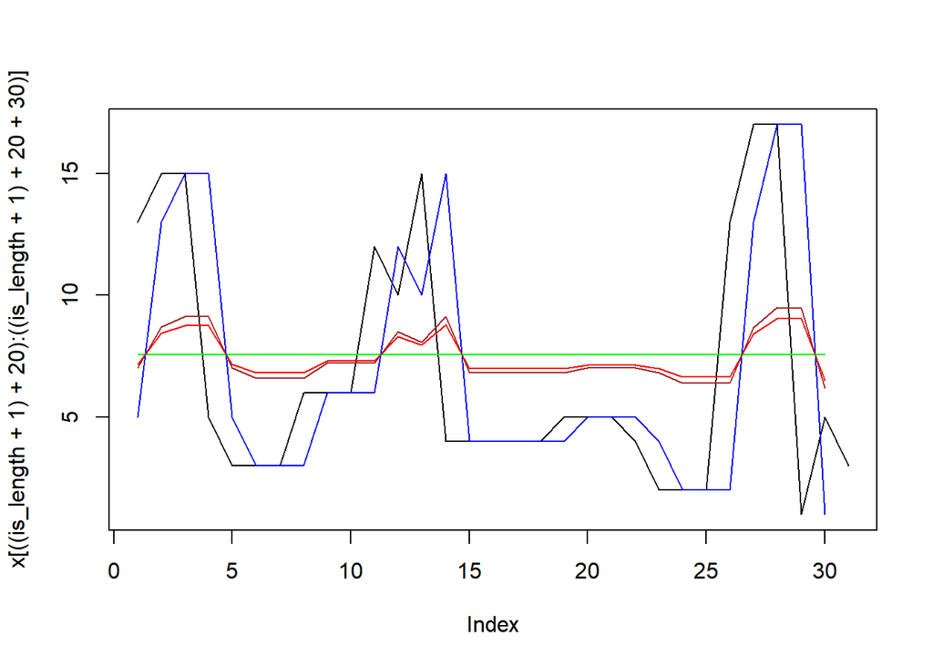

```r
plot(x[((is_length+1)+20):((is_length+1)+20+30)],type="l")
#lines(CondMean[1:100,10])
lines(CondMean[(1+20):(30+20),20],col="red")
lines(NaiveFC[(1+20):(30+20),20],col="blue")
lines(NaiveMeanFC[(1+20):(30+20),20],col="green")
lines(CondMean_linear[(1+20):(30+20),20],col="brown")
```

Time for this code chunk to run: 0.697064876556396

## Comparing the nonparametric forecasts with a parametric forecast

```r
library(trawl)
```

Time for this code chunk to run: 0.030890941619873 We fit a NegBin trawl model with exponential trawl function first, before considering a supOU trawl function.

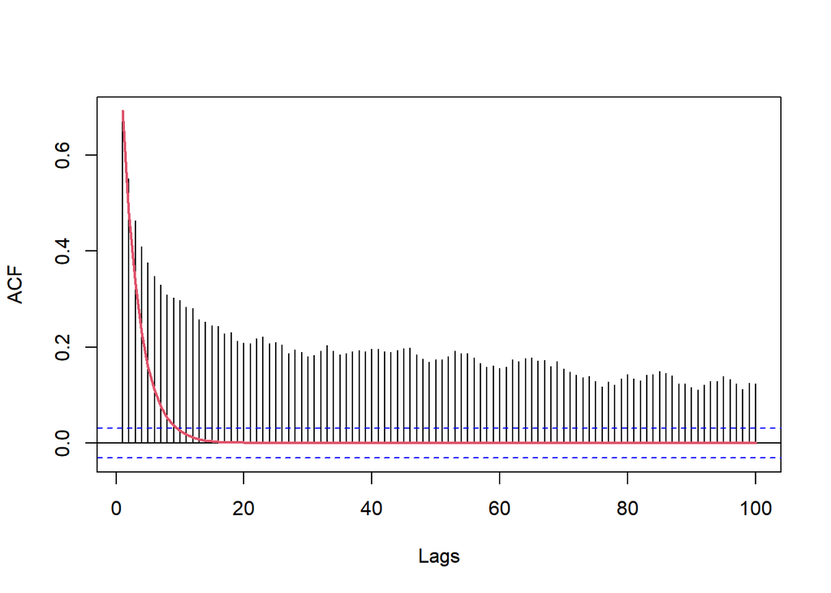

```r
  data <-x

  #Estimate trawl function parameters
  esttrawlfct_fc <- fit_Exptrawl(data, Delta=my_Delta, plot=TRUE) #estimated trawl   function for forecasting
```

```r
  my_lambda <- esttrawlfct_fc$lambda
  my_lambda
```

```
## [1] 4.420998
```

```r
  #Estimate the Lebesgue measure of the trawl set (components)
  lebA_fc_c1 <-1/my_lambda
  lebA_fc_c1
```

```
## [1] 0.2261933
```

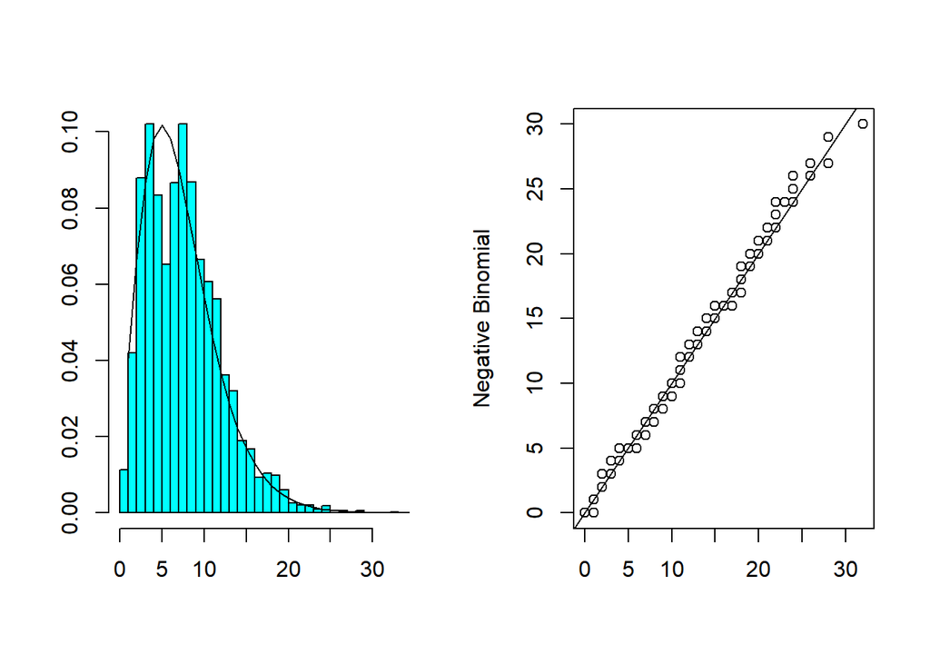

```r
  #Estimate negaitve binomial parameters
  negbinpar <- fit_marginalNB(data, lebA_fc_c1, plot=TRUE)
```

```r
  my_theta <- negbinpar$theta
  my_m <- negbinpar$m
  my_mtilde <- (1-my_theta)^2/my_theta

  my_c <- my_theta*my_m/(1-my_theta)^2

  lebA_fc <-lebA_fc_c1*my_c

  my_theta
```

```
##           [,1]
## [1,] 0.6290937
```

```r
  my_m
```

```
##          [,1]
## [1,] 18.64213
```

```r
  my_mtilde
```

```
##          [,1]
## [1,] 0.218682
```

```r
  my_c
```

```
##          [,1]
## [1,] 85.24768
```

```r
 lebA_fc
```

```
##          [,1]
## [1,] 19.28245
```

Time for this code chunk to run: 2.8190598487854

We fit a NegBin trawl model with supOU trawl function. We first fit such a model to the full sample.

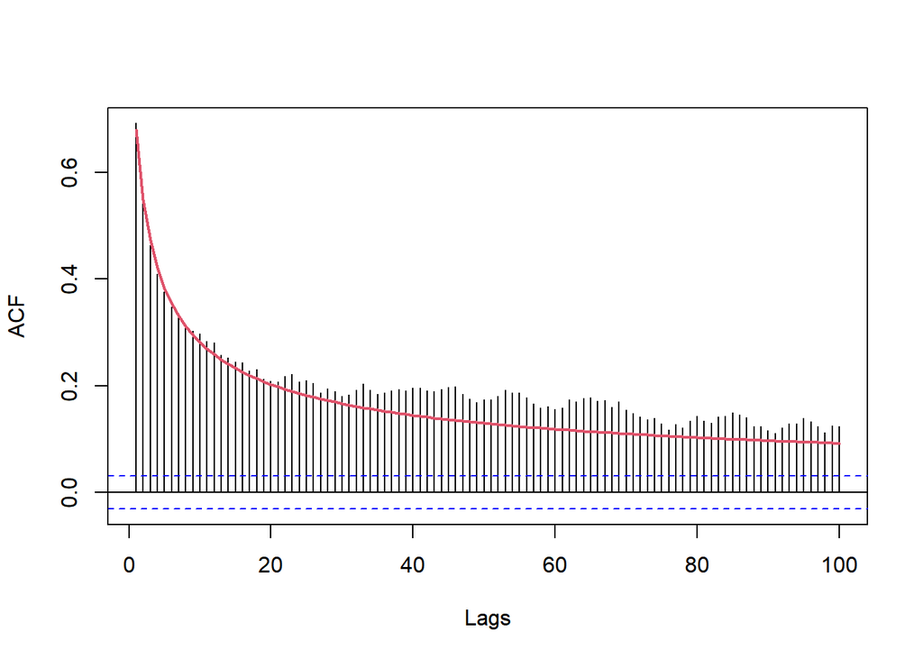

```r
  data <-x

  #Estimate trawl function parameters
  esttrawlfct_fc <- fit_LMtrawl(data, Delta=my_Delta, GMMlag=10,plot=TRUE) #estimated trawl   function for forecasting
```

```r
  my_alpha <- esttrawlfct_fc$alpha
  my_alpha
```

```
## [1] 0.07189778
```

```r
  my_H <- esttrawlfct_fc$H
  my_H
```

```
## [1] 1.501237
```

```r
  #Estimate the Lebesgue measure of the trawl set (components)
  lebA_fc_c1 <-my_alpha/(my_H-1)
  lebA_fc_c1
```

```
## [1] 0.1434407
```

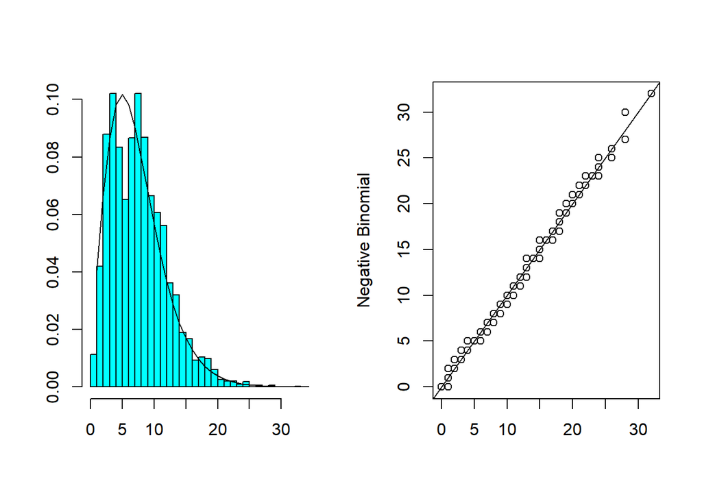

```r
  #Estimate negaitve binomial parameters
  negbinpar <- fit_marginalNB(data, lebA_fc_c1, plot=TRUE)
```

```r
  my_theta <- negbinpar$theta
  my_m <- negbinpar$m
  my_mtilde <- (1-my_theta)^2/my_theta

  my_c <- my_theta*my_m/(1-my_theta)^2

  lebA_fc <-lebA_fc_c1*my_c

  my_theta
```

```
##           [,1]
## [1,] 0.6290937
```

```r
  my_m
```

```
##          [,1]
## [1,] 29.39698
```

```r
  my_mtilde
```

```
##          [,1]
## [1,] 0.218682
```

```r
  my_c
```

```
##         [,1]
## [1,] 134.428
```

```r
 lebA_fc
```

```
##          [,1]
## [1,] 19.28245
```

Time for this code chunk to run: 1.78937888145447

Next we fit a NegBin trawl model with supOU trawl function to the data using the same rolling window as in the nonparametric set-up.

```r
is_length <- 3000 #in sample length

my_lag <-is_length-1
my_Delta <-1/12#sampling in 5s=1/12 min




hrange <- 20
noos <- n-is_length-hrange #=941 for is_length=3000

#noos <- 4
#Create forecast matrices:
CondMean_p <-matrix(0, nrow=noos, ncol=hrange)
CondMean_IV_p <-matrix(0, nrow=noos, ncol=hrange)

ActualValues <- matrix(0, nrow=noos, ncol=hrange)

Weight_Intersection_p <- matrix(0, nrow=noos, ncol=hrange)
Weight_SetDifference_p <- matrix(0, nrow=noos, ncol=hrange)

parvec_alpha <-numeric(noos)
parvec_H <- numeric(noos)
parvec_theta <- numeric(noos)
parvev_m <- numeric(noos)
parvec_mtilde <-numeric(noos)
parvec_c <- numeric(noos)
parvec_lebA <-numeric(noos)

set.seed(1)

for(tau in 1:noos){
#tau<-1


  data <-x[tau:(is_length+tau-1)] # take new subsample of length is_length
  actualvalue <- x[(is_length+tau-1)]
  #datamean <- mean(data) #sum(data)/(is_length) is also correct


  #Estimate trawl function parameters
  esttrawlfct_fc <- fit_LMtrawl(data, Delta=my_Delta, GMMlag=10) #estimated trawl   function for forecasting

  my_alpha <- esttrawlfct_fc$alpha
  my_H <- esttrawlfct_fc$H

  #Estimate the Lebesgue measure of the trawl set (components)
  lebA_fc_c1 <-my_alpha/(my_H-1)

  #Estimate negaitve binomial parameters
  negbinpar <- fit_marginalNB(data, lebA_fc_c1)

  my_theta <- negbinpar$theta
  my_m <- negbinpar$m
  my_mtilde <- (1-my_theta)^2/my_theta

  my_c <- my_theta*my_m/(1-my_theta)^2

  lebA_fc <-lebA_fc_c1*my_c

  parvec_alpha[tau] <-my_alpha
  parvec_H[tau] <- my_H
  parvec_theta[tau] <- my_theta
  parvev_m[tau] <- my_m
  parvec_mtilde[tau] <-my_mtilde
  parvec_c[tau] <- my_c
  parvec_lebA[tau] <-lebA_fc

  for(h in 1:hrange){ #forecasting horizon loop in 1:hrange
#h<-1
    #Estimate Leb(A intersection A_h)

    lebAintersection_fc <-my_c*my_alpha/(my_H-1)*(1+h*my_Delta/my_alpha)^(1-my_H)


    #Estimate Leb(A \ A_h)

    lebAsetdiff_fc <-lebA_fc-lebAintersection_fc



    #ActualValue
    ActualValues[tau,h]<- x[(is_length+tau-1+h)]
    #Compute forecast(s)

    #trawl formula


    Weight_Intersection_p[tau, h]<-lebAintersection_fc/lebA_fc
    Weight_SetDifference_p[tau,h]<-lebAsetdiff_fc/lebA_fc


    CondMean_p[tau,h] <- actualvalue*Weight_Intersection_p[tau, h]+(1-my_theta)*lebA_fc*Weight_SetDifference_p[tau,h]

    CondMean_IV_p[tau,h]<-round(CondMean_p[tau,h])



  } #end for h

}#end for tau
```

Time for this code chunk to run: 10.6976162195206